# Python_Scikit-learn

### KNN Classifier - IRIS

#### Processes:

1. **Import module:**
   - datasets, train_test_split, KNeighborsClassifier
2. **Create Data:**
   - classes, labels
   - Data set --> training set/data, testing set/data
3. **Create Model:**
   - fit, predict
4. **Visualization**

#### sklear.cross_validation:

##### train_test_split(*array, **options):

To avoid **overfitting**, it is common practice when performing a (supervised) machine learning experiment to hold out part of the available data as a **test set** *X_test, y_test*.

Parameters:

- *arrays: Allowed inputs are lists, numpy arrays, scipy-sparse matrices or pandas dataframes
- **test_size:** float, int, None, optional
- **train_size:** float, int, None, default None
- **random_state:** int, RandomState instance or None, optional(default=None)
- **shuffle:** boolean, optional(default=True)

  Whether or not to shuffle the data before splitting. If shuffle=False then stratify must be None.
- **stratify:** array-like or None (default is None)

Returns:

- **splitting:** list, length=2 * len(arrays)

  List containing train-test split of inputs

#### sklearn.neighbors:

##### It provides functionality for unsupervised and supervised neighbors-based learning methods.

(The principle behind nearest neighbor methods is to find a predefined number of training samples closest in distance to the new point, and predict the label from these.)

**Unsupervised nearest neighbors:** It's the foundation of many other learning methods, notably manifold learning and spectral clustering.

**Supervised neighbors-based learning:** It comes in two flavors: *classification* for data with discrete labels, and *regression* for data with continuous labels.

*sklearn.neighbors.**KNeighborsClassifier***(n_neighbors=5, weights='uniform', algorithm='auto', leaf_size=30, p=2,, metric='minkowski', metric_params=None, n_jobs=1, **kwargs):

Classifier implementing the k-nearest neighbors vote.

#### sklearn.prepocessing:

##### It provides several common utility functions and transformer classes to change raw feature vectors into a representation that is more suitable for the downstream estimators.

Learning algorithms benefit from standardization of the data set. (ex: dealing with outliers)

sklearn.preprocessing.**StandardScaler**(copy=True, with_mean=True, with_std=True)

Standardize features by removing the mean and scalling to unit variance. (normally distributed data, ex: **Gaussian with 0 mean and unit variance**,(X-X_mean)/X_std)

Centering and scaling happen independently on each feature by computing the relevant statistics on the samples in the training set. Mean and standard deviation are then stored to be used on later data using the transformer method.

Parameters:

- **copy:** boolean, optional, default True
- **with_mean:** boolean, default True  
  If True, center the data before scaling.
- **with_std:** boolean, default True  
  If True, scale the data to unit variance (or equivalently, unit standard deviation)

Attributes

- **scale :** ndarray, shape[n features]  
  Per feature relative scaling of the data
- **mean :** array of floats with shape [n features]  
  The mean value for each feature in the training set.
- **var :** array of floats with shape [n features]  
  The variance for each feature in the training set
- **n_samples_seen:** int  
  The number of samples processed by the estimator.

```python
import numpy as np
from sklearn import datasets
from sklearn.model_selection import train_test_split
from sklearn.neighbors import KNeighborsClassifier
from sklearn.preprocessing import StandardScaler
import matplotlib.pyplot as plt
```

```python
iris = datasets.load_iris()
# print(iris)
print(iris.target_names)
print(iris.feature_names)
iris_X = iris.data
iris_y = iris.target
print(len(iris_X))
print(len(iris_y))
```

```
['setosa' 'versicolor' 'virginica']
['sepal length (cm)', 'sepal width (cm)', 'petal length (cm)', 'petal width (cm)']
150
150
```

```python
X_train, X_test, y_train, y_test = train_test_split(iris_X, iris_y, test_size=0.3)
print(len(X_train))
# print(X_train)
print(len(y_train))
```

```
105
105
```

```python
#Standardize
sc = StandardScaler()
sc.fit(X_train)

# X_train's mean values of each feature
X_train_mean = X_train.mean(axis=0)
print(X_train_mean)
print(sc.mean_)

# X_train's variance for each feature
print(sc.var_)

# X_train's standard deviation of each feature
X_train_std = X_train.std(axis=0)
print(X_train_std)
print(sc.scale_)

# transform X_train and X_test
X_train_standard = sc.transform(X_train)
X_test_standard = sc.transform(X_test)
```

```
[ 5.87333333  3.10952381  3.75619048  1.19428571]
[ 5.87333333  3.10952381  3.75619048  1.19428571]
[ 0.67643175  0.1926712   3.18265215  0.58396735]
[ 0.82245471  0.43894328  1.78399892  0.76417756]
[ 0.82245471  0.43894328  1.78399892  0.76417756]
```

```python
knn = KNeighborsClassifier()
# Fit the module using X as training data and y as target values
knn.fit(X_train_standard, y_train)
print(knn.fit(X_train_standard, y_train))

# Predict the class labels for the provided data
y_predict = knn.predict(X_test_standard)
print(len(y_predict))
print(y_predict)

#compare y_predict and y_test
print(y_test)
print(y_test!=y_predict)
print('Misclassified samples: %d'%(y_test!=y_predict).sum())
```

```
KNeighborsClassifier(algorithm='auto', leaf_size=30, metric='minkowski',
           metric_params=None, n_jobs=1, n_neighbors=5, p=2,
           weights='uniform')
45
[2 0 2 1 0 0 1 1 2 0 0 1 1 1 1 2 2 0 2 0 1 2 2 1 0 2 2 0 0 0 2 0 1 2 1 1 1
 1 2 1 2 0 1 0 0]
[1 0 2 2 0 0 1 1 2 0 0 1 2 1 1 2 2 0 2 0 2 1 2 1 0 2 2 0 0 0 2 0 1 2 1 2 1
 1 2 1 2 0 1 0 0]
[ True False False  True False False False False False False False False
  True False False False False False False False  True  True False False
 False False False False False False False False False False False  True
 False False False False False False False False False]
Misclassified samples: 6
```

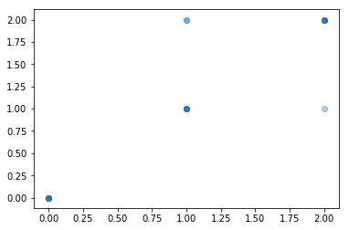

```python
# Visualization
plt.scatter(y_predict, y_test, alpha=0.2)
plt.show()
```

```python
index_diff = np.where(y_test!=y_predict)
array_diff = np.array([])
print(type(index_diff))
print(len(index_diff))
print(type(index_diff[0]))

for i in index_diff[0]:
    print(y_test[i], y_predict[i])
    np.append(array_diff, [[y_test[i], y_predict[i]]])
    print(array_diff)

# for i in np
```

```
<class 'tuple'>
1
<class 'numpy.ndarray'>
1 2
```

[output not shown]